# Ford GoBike System Data Exploration

## Preliminary Wrangling

In this project, I will explore the Ford GoBike System Data of year 2018.This dataset includes information about each trip in a bike-sharing system in greater San Francisco Bay area.

```python
# import all packages and set plots to be embedded inline
import numpy as np
import pandas as pd
import matplotlib.pyplot as plt
import seaborn as sb
import glob
import zipfile

%matplotlib inline
sb.set_context('talk')
```

```python
# unzip the data file
for i in glob.glob('data/*.zip'):
    with zipfile.ZipFile(i, 'r') as myzip:
        myzip.extractall()
```

```python
# read all csv file into one DataFrame
df_orig = pd.DataFrame()
csv_list = []
for i in glob.glob('*.csv'):
    df_single = pd.read_csv(i)
    csv_list.append(df_single)
df_orig = pd.concat(csv_list, ignore_index=True)
```

### Assess the Data

```python
df_orig.head()
```

|  | duration_sec | start_time | end_time | start_station_id | start_station_name | start_station_latitude | start_station_longitude | end_station_id | end_station_name | end_station_latitude | end_station_longitude | bike_id | user_type | member_birth_year | member_gender | bike_share_for_all_trip |
| --- | --- | --- | --- | --- | --- | --- | --- | --- | --- | --- | --- | --- | --- | --- | --- | --- |
| 0 | 75284 | 2018-01-31 22:52:35.2390 | 2018-02-01 19:47:19.8240 | 120.0 | Mission Dolores Park | 37.761420 | -122.426435 | 285.0 | Webster St at O'Farrell St | 37.783521 | -122.431158 | 2765 | Subscriber | 1986.0 | Male | No |
| 1 | 85422 | 2018-01-31 16:13:34.3510 | 2018-02-01 15:57:17.3100 | 15.0 | San Francisco Ferry Building (Harry Bridges Pl... | 37.795392 | -122.394203 | 15.0 | San Francisco Ferry Building (Harry Bridges Pl... | 37.795392 | -122.394203 | 2815 | Customer | NaN | NaN | No |
| 2 | 71576 | 2018-01-31 14:23:55.8890 | 2018-02-01 10:16:52.1160 | 304.0 | Jackson St at 5th St | 37.348759 | -121.894798 | 296.0 | 5th St at Virginia St | 37.325998 | -121.877120 | 3039 | Customer | 1996.0 | Male | No |
| 3 | 61076 | 2018-01-31 14:53:23.5620 | 2018-02-01 07:51:20.5000 | 75.0 | Market St at Franklin St | 37.773793 | -122.421239 | 47.0 | 4th St at Harrison St | 37.780955 | -122.399749 | 321 | Customer | NaN | NaN | No |
| 4 | 39966 | 2018-01-31 19:52:24.6670 | 2018-02-01 06:58:31.0530 | 74.0 | Laguna St at Hayes St | 37.776435 | -122.426244 | 19.0 | Post St at Kearny St | 37.788975 | -122.403452 | 617 | Subscriber | 1991.0 | Male | No |

```python
df_orig.tail()
```

|  | duration_sec | start_time | end_time | start_station_id | start_station_name | start_station_latitude | start_station_longitude | end_station_id | end_station_name | end_station_latitude | end_station_longitude | bike_id | user_type | member_birth_year | member_gender | bike_share_for_all_trip |
| --- | --- | --- | --- | --- | --- | --- | --- | --- | --- | --- | --- | --- | --- | --- | --- | --- |
| 1396760 | 273 | 2018-09-01 00:18:07.1150 | 2018-09-01 00:22:40.4760 | 141.0 | Valencia St at Cesar Chavez St | 37.747998 | -122.420219 | 144.0 | Precita Park | 37.747300 | -122.411403 | 3263 | Subscriber | 1970.0 | Male | No |
| 1396761 | 333 | 2018-09-01 00:16:13.9860 | 2018-09-01 00:21:47.1410 | 182.0 | 19th Street BART Station | 37.809013 | -122.268247 | 178.0 | Broadway at 30th St | 37.819381 | -122.261928 | 452 | Subscriber | 1986.0 | Male | No |
| 1396762 | 380 | 2018-09-01 00:14:04.4020 | 2018-09-01 00:20:24.6780 | NaN | NaN | 37.410000 | -121.960000 | NaN | NaN | 37.420000 | -121.950000 | 4233 | Customer | 1983.0 | Male | No |
| 1396763 | 568 | 2018-09-01 00:02:44.1480 | 2018-09-01 00:12:12.6110 | 81.0 | Berry St at 4th St | 37.775880 | -122.393170 | 87.0 | Folsom St at 13th St | 37.769757 | -122.415674 | 2530 | Customer | 1990.0 | Male | No |
| 1396764 | 287 | 2018-09-01 00:00:11.8510 | 2018-09-01 00:04:59.5010 | 115.0 | Jackson Playground | 37.765026 | -122.398773 | 126.0 | Esprit Park | 37.761634 | -122.390648 | 2912 | Customer | 1987.0 | Female | No |

```python
df_orig.info()
```

```
<class 'pandas.core.frame.DataFrame'>
RangeIndex: 1396765 entries, 0 to 1396764
Data columns (total 16 columns):
duration_sec               1396765 non-null int64
start_time                 1396765 non-null object
end_time                   1396765 non-null object
start_station_id           1387026 non-null float64
start_station_name         1387026 non-null object
start_station_latitude     1396765 non-null float64
start_station_longitude    1396765 non-null float64
end_station_id             1387026 non-null float64
end_station_name           1387026 non-null object
end_station_latitude       1396765 non-null float64
end_station_longitude      1396765 non-null float64
bike_id                    1396765 non-null int64
user_type                  1396765 non-null object
member_birth_year          1304810 non-null float64
member_gender              1305147 non-null object
bike_share_for_all_trip    1396765 non-null object
dtypes: float64(7), int64(2), object(7)
memory usage: 170.5+ MB
```

```python
df_orig.describe()
```

|  | duration_sec | start_station_id | start_station_latitude | start_station_longitude | end_station_id | end_station_latitude | end_station_longitude | bike_id | member_birth_year |
| --- | --- | --- | --- | --- | --- | --- | --- | --- | --- |
| count | 1.396765e+06 | 1.387026e+06 | 1.396765e+06 | 1.396765e+06 | 1.387026e+06 | 1.396765e+06 | 1.396765e+06 | 1.396765e+06 | 1.304810e+06 |
| mean | 8.825069e+02 | 1.169855e+02 | 3.776707e+01 | -1.223492e+02 | 1.154826e+02 | 3.776719e+01 | -1.223487e+02 | 2.222074e+03 | 1.982818e+03 |
| std | 2.516952e+03 | 9.791467e+01 | 1.052730e-01 | 1.770016e-01 | 9.795242e+01 | 1.051614e-01 | 1.766444e-01 | 1.214644e+03 | 1.047095e+01 |
| min | 6.100000e+01 | 3.000000e+00 | 3.726331e+01 | -1.224737e+02 | 3.000000e+00 | 3.726331e+01 | -1.224737e+02 | 1.100000e+01 | 1.881000e+03 |
| 25% | 3.520000e+02 | 3.100000e+01 | 3.777106e+01 | -1.224113e+02 | 3.000000e+01 | 3.777106e+01 | -1.224094e+02 | 1.199000e+03 | 1.977000e+03 |
| 50% | 5.590000e+02 | 8.700000e+01 | 3.778127e+01 | -1.223974e+02 | 8.600000e+01 | 3.778127e+01 | -1.223971e+02 | 2.302000e+03 | 1.985000e+03 |
| 75% | 8.810000e+02 | 1.820000e+02 | 3.779728e+01 | -1.222852e+02 | 1.820000e+02 | 3.779728e+01 | -1.222880e+02 | 3.248000e+03 | 1.990000e+03 |
| max | 8.636600e+04 | 3.740000e+02 | 4.551000e+01 | -7.357000e+01 | 3.740000e+02 | 4.551000e+01 | -7.357000e+01 | 4.466000e+03 | 2.000000e+03 |

```python
df_orig.member_gender.unique()
```

```
array(['Male', nan, 'Female', 'Other'], dtype=object)
```

There are a few quality issues need to be cleaned:

- 'start_time' and 'end_time' datatype is string but not datetime
- 'bike_id' datatype is integer but not string
- 'member_birth_year' datatype is float but not integer. This is caused by "NaN can't be stored in an integer array". We will not fix this issue then
- 'start_station_id', 'start_station_name' , 'end_station_id', 'end_station_name' information is not very helpful for this project. Those columns can be removed
- Missing values in columns 'member_birth_year', 'member_gender'
- 'member_gender' column has 'Other' value

### Clean the Data

```python
# make a copy of the dataset
df = df_orig.copy()
```

- Remove 'start_station_id', 'start_station_name' , 'end_station_id', 'end_station_name' columns

```python
keep_list = ['duration_sec', 'start_time', 'end_time',
       'start_station_latitude',
       'start_station_longitude',
       'end_station_latitude', 'end_station_longitude', 'bike_id', 'user_type',
       'member_birth_year', 'member_gender', 'bike_share_for_all_trip']

df = df_orig[keep_list]
```

- convert 'start_time' and 'end_time' datatype to datetime
- convert 'bike_id' datatype to string

```python
df.start_time = pd.to_datetime(df_orig.start_time)
df.end_time = pd.to_datetime(df_orig.end_time)
df.bike_id = df_orig.bike_id.astype(str)
```

- Replace 'Other' value in 'member_gender' column with NaN

```python
df.member_gender.replace("Other", np.nan, inplace=True)
df.member_gender.unique()
```

```
array(['Male', nan, 'Female'], dtype=object)
```

```python
df.info()
```

```
<class 'pandas.core.frame.DataFrame'>
RangeIndex: 1396765 entries, 0 to 1396764
Data columns (total 12 columns):
duration_sec               1396765 non-null int64
start_time                 1396765 non-null datetime64[ns]
end_time                   1396765 non-null datetime64[ns]
start_station_latitude     1396765 non-null float64
start_station_longitude    1396765 non-null float64
end_station_latitude       1396765 non-null float64
end_station_longitude      1396765 non-null float64
bike_id                    1396765 non-null object
user_type                  1396765 non-null object
member_birth_year          1304810 non-null float64
member_gender              1285040 non-null object
bike_share_for_all_trip    1396765 non-null object
dtypes: datetime64[ns](2), float64(5), int64(1), object(4)
memory usage: 127.9+ MB
```

```python
df.head()
```

|  | duration_sec | start_time | end_time | start_station_latitude | start_station_longitude | end_station_latitude | end_station_longitude | bike_id | user_type | member_birth_year | member_gender | bike_share_for_all_trip |
| --- | --- | --- | --- | --- | --- | --- | --- | --- | --- | --- | --- | --- |
| 0 | 75284 | 2018-01-31 22:52:35.239 | 2018-02-01 19:47:19.824 | 37.761420 | -122.426435 | 37.783521 | -122.431158 | 2765 | Subscriber | 1986.0 | Male | No |
| 1 | 85422 | 2018-01-31 16:13:34.351 | 2018-02-01 15:57:17.310 | 37.795392 | -122.394203 | 37.795392 | -122.394203 | 2815 | Customer | NaN | NaN | No |
| 2 | 71576 | 2018-01-31 14:23:55.889 | 2018-02-01 10:16:52.116 | 37.348759 | -121.894798 | 37.325998 | -121.877120 | 3039 | Customer | 1996.0 | Male | No |
| 3 | 61076 | 2018-01-31 14:53:23.562 | 2018-02-01 07:51:20.500 | 37.773793 | -122.421239 | 37.780955 | -122.399749 | 321 | Customer | NaN | NaN | No |
| 4 | 39966 | 2018-01-31 19:52:24.667 | 2018-02-01 06:58:31.053 | 37.776435 | -122.426244 | 37.788975 | -122.403452 | 617 | Subscriber | 1991.0 | Male | No |

### What is the structure of your dataset?

There are $1396765$ trips information in this dataset. There are 12 variables / columns. From the dataset we have the following information about each trip:

- Trip duration, start and end time
- Trip start and end location
- Bike information
- User information

### What is/are the main feature(s) of interest in your dataset?

I am interested in investigating the relationship of 'duration_sec' with the other features. I am also interested in the number of trips during different time frame.

### What features in the dataset do you think will help support your investigation into your feature(s) of interest?

I would expect that subscribed users ride duration is longer than subscribed users. It is also likely that ride duration varies among different age groups and genders.  
The time of the day, day of the week, month of the year may also have effects on ride duration and number of trips.

## Univariate Exploration

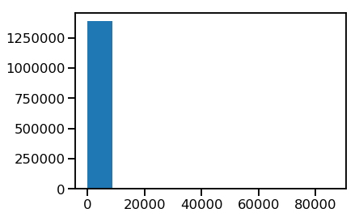

```python
plt.hist(df['duration_sec']);
```

There are many outliers in duration_sec, which makes it hard to visualization the distribution. I will take look at the interquartile range by using box plot.

```python
df['duration_sec'].describe(percentiles = [.1, .2, .3, .4, .5, .6, .7, .8, .9, .95, 1])
```

```
count    1.396765e+06
mean     8.825069e+02
std      2.516952e+03
min      6.100000e+01
10%      2.300000e+02
20%      3.140000e+02
30%      3.900000e+02
40%      4.710000e+02
50%      5.590000e+02
60%      6.620000e+02
70%      7.960000e+02
80%      9.870000e+02
90%      1.362000e+03
95%      1.858000e+03
100%     8.636600e+04
max      8.636600e+04
Name: duration_sec, dtype: float64
```

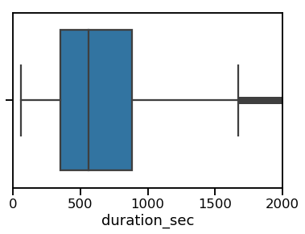

```python
sb.boxplot(data=df, x='duration_sec');
plt.xlim(0,2000);
```

I will use 1900 seconds as the cut-off line to remove the outliers.  
duration_sec < 1900 represents more than 95% of the data.

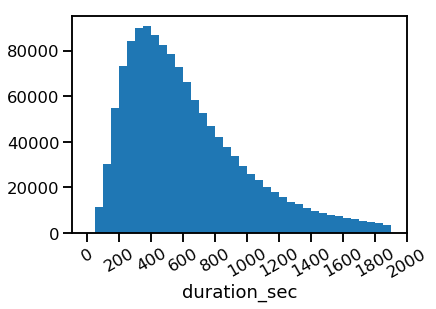

```python
df = df[df['duration_sec'] < 1900]
bins = np.arange(0, df['duration_sec'].max()+50, 50)
plt.hist(df['duration_sec'], bins=bins);
plt.xticks(np.arange(0, df['duration_sec'].max()+200, 200), rotation=30);
plt.xlabel('duration_sec');
```

I create a new variable duration_min to convert the duration from seconds to minutes. This will help people understand the duration more easily.

```python
df['duration_min'] = df['duration_sec'] / 60.0
```

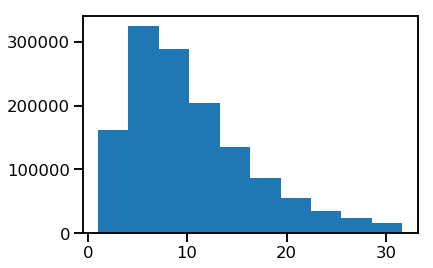

```python
plt.hist(df['duration_min']);
```

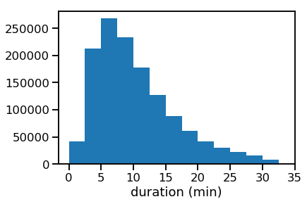

```python
bins = np.arange(0, df['duration_min'].max()+2.5, 2.5)
plt.hist(df['duration_min'], bins=bins);
plt.xticks(np.arange(0, df['duration_min'].max()+5, 5), rotation=0);
plt.xlabel('duration (min)');
```

Since the distribution is right skewed, I will use log scale on x-axis to get a better visualization.

```python
np.log10(df['duration_min'].describe())
```

```
count    6.123834
mean     1.016144
std      0.791828
min      0.007179
25%      0.757143
50%      0.951823
75%      1.134602
max      1.500374
Name: duration_min, dtype: float64
```

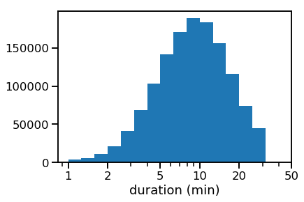

```python
bins = 10 ** np.arange(0, np.log10(df['duration_min'].max())+0.1, 0.1)

plt.hist(data=df, x='duration_min', bins=bins)
plt.xscale('log')
plt.xlabel('duration (min)');
plt.xticks([1, 2, 5, 10, 20, 50], [1, 2, 5, 10, 20, 50]);
```

Duration distribution is unimodal and right skewed. The peak is between 5 to 10 minutes. At the end of the distribution, it is not smooth out because it is truncated (< 1900 seconds)

Now, I will take a look at the age and gender distribution.

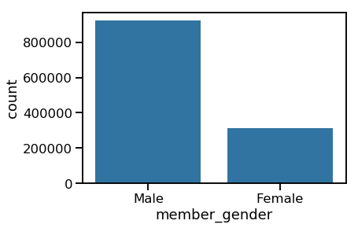

```python
default_color = sb.color_palette()[0]
sb.countplot(data=df, x='member_gender', color=default_color);
```

The ride numbers of male is more than twice as the ride numbers of female.

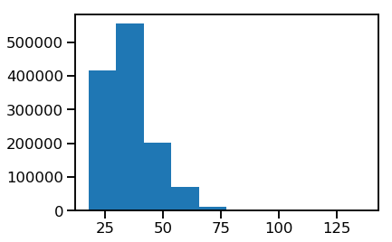

```python
# Create age column
current_year = int(pd.to_datetime('today').strftime("%Y"))
df['age'] = current_year - df['member_birth_year']

plt.hist(data=df, x='age');
```

It doesn’t make sense that some bike riders are more than 100 years old. Those could be inaccurate data. I will remove the outliers.

```python
df['age'].describe(percentiles = [.1, .2, .3, .4, .5, .6, .7, .8, .9, .95, 1])
```

```
count    1.257138e+06
mean     3.517484e+01
std      1.041243e+01
min      1.800000e+01
10%      2.400000e+01
20%      2.700000e+01
30%      2.900000e+01
40%      3.100000e+01
50%      3.300000e+01
60%      3.500000e+01
70%      3.800000e+01
80%      4.300000e+01
90%      5.000000e+01
95%      5.600000e+01
100%     1.370000e+02
max      1.370000e+02
Name: age, dtype: float64
```

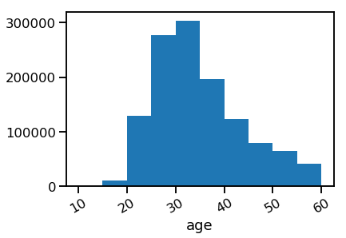

```python
df = df[df['age'] < 60]
bins = np.arange(10, df['age'].max()+5, 5)
plt.hist(df['age'], bins=bins);
plt.xticks(np.arange(10, df['age'].max()+10, 10), rotation=30);
plt.xlabel('age');
```

Duration distribution is unimodal and right skewed. The peak is between 25 to 35 years old.

Next, let's take a look at the user type variable

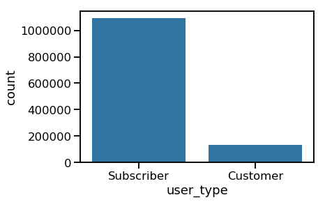

```python
sb.countplot(data=df, x='user_type', color=default_color);
```

Most of the bike rides are from subscriber. It makes sense as subscriber would rider more frequently compared to customer.

Finally, I will take a look at the trips count in terms of time of day, day of the week, and month of the year.

```python
# Create 3 new columns
df['time_day'] = df['start_time'].dt.hour
df['weekday'] = df['start_time'].dt.weekday_name
df['month'] =df['start_time'].dt.month
```

```python
# Convert 'weekday' to ordered categorical type
weekday_list = ['Monday', 'Tuesday', 'Wednesday', 'Thursday','Friday','Saturday','Sunday']
weekday_order = pd.api.types.CategoricalDtype(ordered=True, categories=weekday_list)
df['weekday'] = df['weekday'].astype(weekday_order);
```

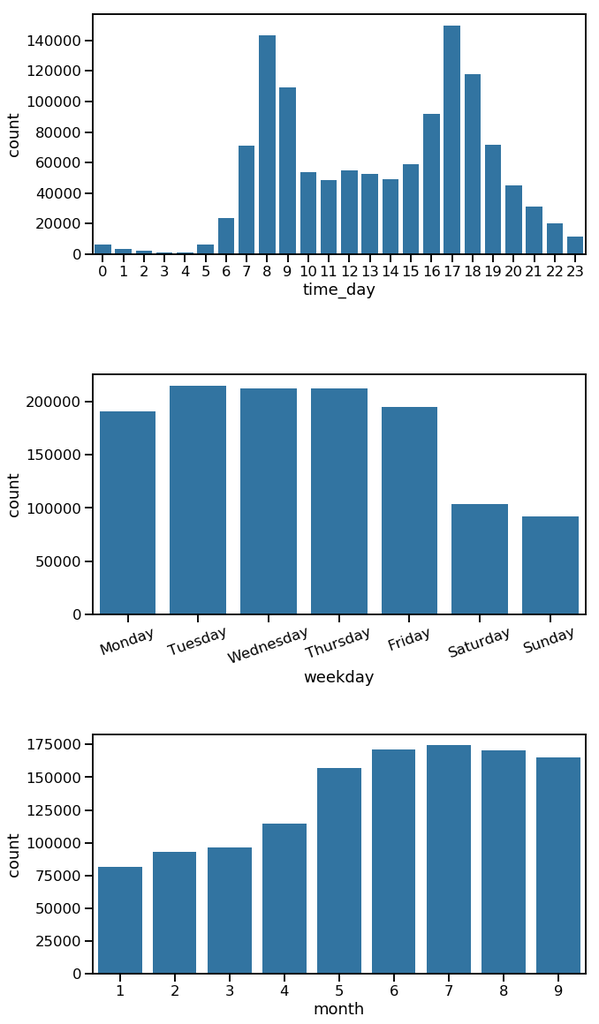

```python
plt.figure(figsize=(10,20))

plt.subplot(3,1,1)
sb.countplot(data=df, x='time_day', color=default_color);

plt.subplot(3,1,2)
sb.countplot(data=df, x='weekday', color=default_color);
plt.xticks(rotation=20)

plt.subplot(3,1,3)
sb.countplot(data=df, x='month', color=default_color);
plt.subplots_adjust(hspace=0.5)
```

The distribution of time of day is bimodal, the first peak is around 8am, second peak is around 5pm.  
The bar plot of weekday shows that more trips in workdays than in weekends.  
The number of trip of month is gradually increasing from January to June. Then it stays stably.

### Discuss the distribution(s) of your variable(s) of interest. Were there any unusual points? Did you need to perform any transformations?

The variable duration_sec has many outliers. I took a look at the interquartile range and truncate the outliers. I also create a new column duration_min to convert the duration from seconds to minutes for easy understanding purpose. Since the distribution is right skewed, I used log transformation.

### Of the features you investigated, were there any unusual distributions? Did you perform any operations on the data to tidy, adjust, or change the form of the data? If so, why did you do this?

I created the variable age. I noticed that age variable has some inaccurate data and I cleaned the dataset.

To investigate the trips time in different time frame, I used variable start_time to create 3 more variables time_day, weekday and month.

## Bivariate Exploration

Let's look at the relationship between 2 quantitative variables – duration and age

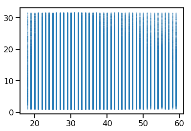

```python
plt.scatter(data=df, x='age', y='duration_min', s=0.2, alpha=0.2);
```

Since there are a lot of data points, and many overlapped data sets, use scatter plot does not give us good visualization. Heat map would be a much better plot.

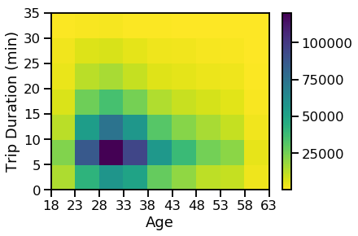

```python
bins_x = np.arange(18, df['age'].max()+5, 5)
bins_y = np.arange(0, df['duration_min'].max()+5, 5)
plt.hist2d(data=df, x='age', y='duration_min', cmap='viridis_r', cmin=0.5, bins=[bins_x, bins_y])
plt.xlabel('Age')
plt.ylabel('Trip Duration (min)')
plt.xticks(np.arange(18, df['age'].max()+5, 5));
plt.yticks(np.arange(0, df['duration_min'].max()+5, 5));

plt.colorbar();
```

When creating the heat map plot, I readjusted the bin sizes and x, y tick marks.  
The darkest color clumps up in 23 - 38 age range, and 0 - 15 duration range, with the darkest bin in 28 - 33 age range, and 5 - 10 duration range.

Next, I will look at how trip duration correlates with some categorical variables

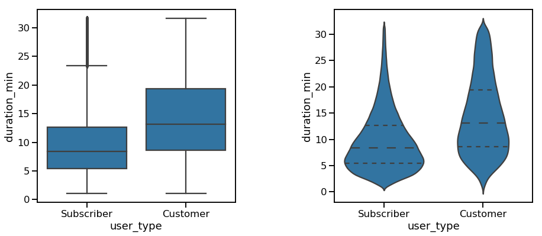

```python
plt.figure(figsize=(15,6))
plt.subplot(1,2,1)
sb.boxplot(data=df, x='user_type', y='duration_min', color=default_color);

plt.subplot(1,2,2)
sb.violinplot(data=df, x='user_type', y='duration_min', color=default_color, inner='quartile');
plt.subplots_adjust(wspace=0.5);
```

Interesting, the subscribers’ trip duration is less than customers’ trip duration. With a violin plot, we can get more insight into the distribution: the positive skew in subscribers, and uniform / high variance in customers

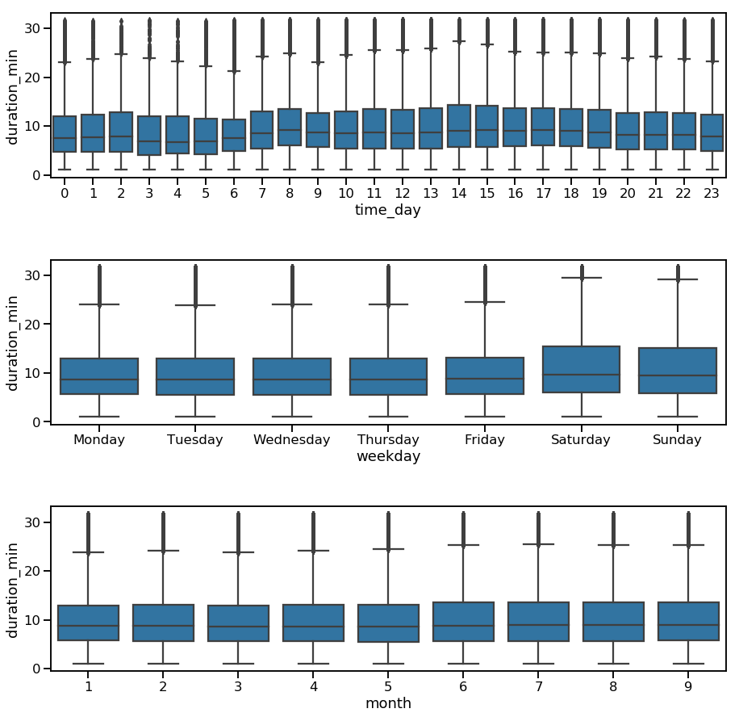

```python
plt.figure(figsize=(15,15))

plt.subplot(3,1,1)
sb.boxplot(data=df, x='time_day', y='duration_min', color=default_color);

plt.subplot(3,1,2)
sb.boxplot(data=df, x='weekday', y='duration_min', color=default_color);


plt.subplot(3,1,3)
sb.boxplot(data=df, x='month', y='duration_min', color=default_color);

plt.subplots_adjust(hspace=0.5);
```

Since there are many categories on x axis, I used box plot instead of violin plot.  
The trip duration does have any obvious differences at different time of the day, day of the week and month of the year.  
We can also use a bar chart to visualize the average trip duration at different time

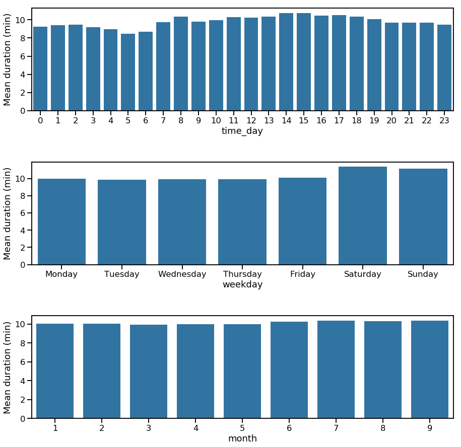

```python
plt.figure(figsize=(15,15))

plt.subplot(3,1,1)
sb.barplot(data=df, x='time_day', y='duration_min', color=default_color, ci=None);
plt.ylabel('Mean duration (min)')

plt.subplot(3,1,2)
sb.barplot(data=df, x='weekday', y='duration_min', color=default_color, ci=None);
plt.ylabel('Mean duration (min)')

plt.subplot(3,1,3)
sb.barplot(data=df, x='month', y='duration_min', color=default_color,ci=None);
plt.ylabel('Mean duration (min)')

plt.subplots_adjust(hspace=0.5);
```

Finally, let’s take a look at the relationships among those non-main features.

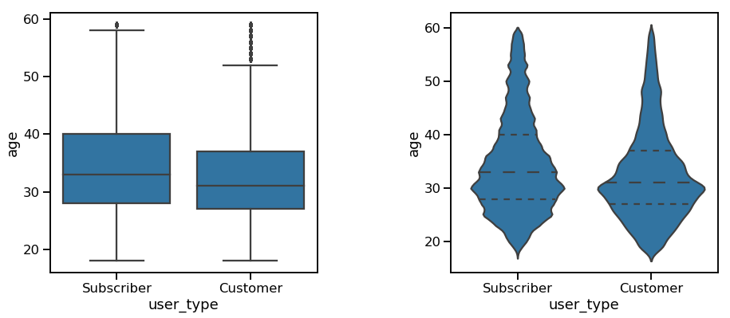

```python
plt.figure(figsize=(15,6))
plt.subplot(1,2,1)
sb.boxplot(data=df, x='user_type', y='age', color=default_color);

plt.subplot(1,2,2)
sb.violinplot(data=df, x='user_type', y='age', color=default_color, inner='quartile');
plt.subplots_adjust(wspace=0.5);
```

Most of the subscribers are slightly older than customers. Both of the distributions are positively skewed. For both user types, the majority of riders’ age is around 30 years old.

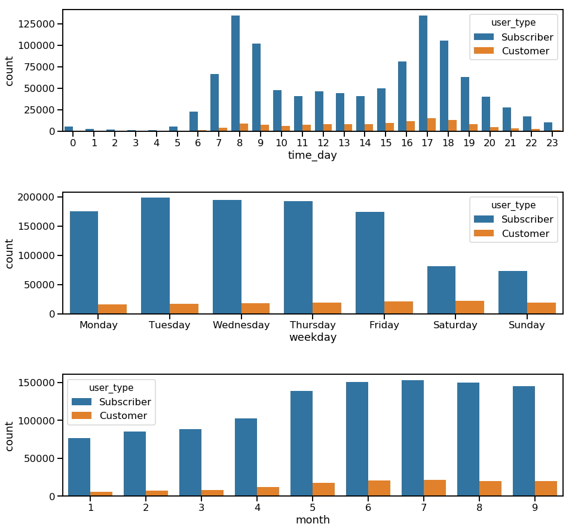

```python
plt.figure(figsize=(15,15))

plt.subplot(3,1,1)
sb.countplot(data=df, x='time_day', hue='user_type');

plt.subplot(3,1,2)
sb.countplot(data=df, x='weekday', hue='user_type');


plt.subplot(3,1,3)
sb.countplot(data=df, x='month', hue='user_type');

plt.subplots_adjust(hspace=0.5);
```

For the subscriber group, the distribution of time of day is bimodal. There are much more trips in workday than weekend. The number of trip of month is gradually increasing from January to June. Then it stays stably.  
For the customer group, however, there is no obvious peak in the distribution of time of day. The number of trips in different days of week falls into a uniform distribution.

### Talk about some of the relationships you observed in this part of the investigation. How did the feature(s) of interest vary with other features in the dataset?

The feature of interest, duration, is correlated to user type. The subscribers’ trip duration is in general less than customers’.  
The most common trip duration is in 5 – 10 minutes. Within this range, the users are mainly 28 – 33 years old.  
The duration does not seem to be correlated to variables time of day, day of week, or month of year.

### Did you observe any interesting relationships between the other features (not the main feature(s) of interest)?

We took a look at the relationship between user type and age. For both user type, the majority of the users are around 30 years old.

## Multivariate Exploration

I want to first explore the relationship among trip duration (feature of interest), age and user type using Faceting Heatmap plot

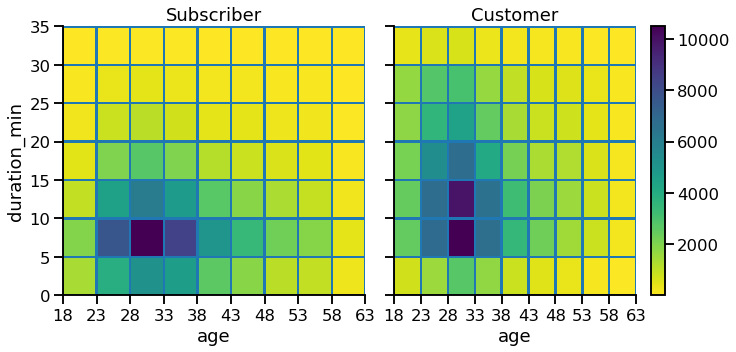

```python
bins_x = np.arange(18, df['age'].max()+5, 5)
bins_y = np.arange(0, df['duration_min'].max()+5, 5)
g = sb.FacetGrid(data=df, col='user_type', size=5)
g.map(plt.hist2d, 'age', 'duration_min', cmap='viridis_r', cmin=0.5, bins=[bins_x, bins_y]);
plt.xticks(np.arange(18, df['age'].max()+5, 5));
plt.yticks(np.arange(0, df['duration_min'].max()+5, 5));
plt.colorbar();

g.set_titles('{col_name}');
```

For subscriber group, the most frequent trip duration is 5-10 minutes. Most of the users are between 28-33 years old.  
For customer group, the most frequent trip duration is 5-15 minutes; the distribution is also not as narrow as the subscriber group. Most of the users are between 28-33 years old, which is the same as the subscriber group.

Next, let’s use time_day and weekday variables to create faceting plots.

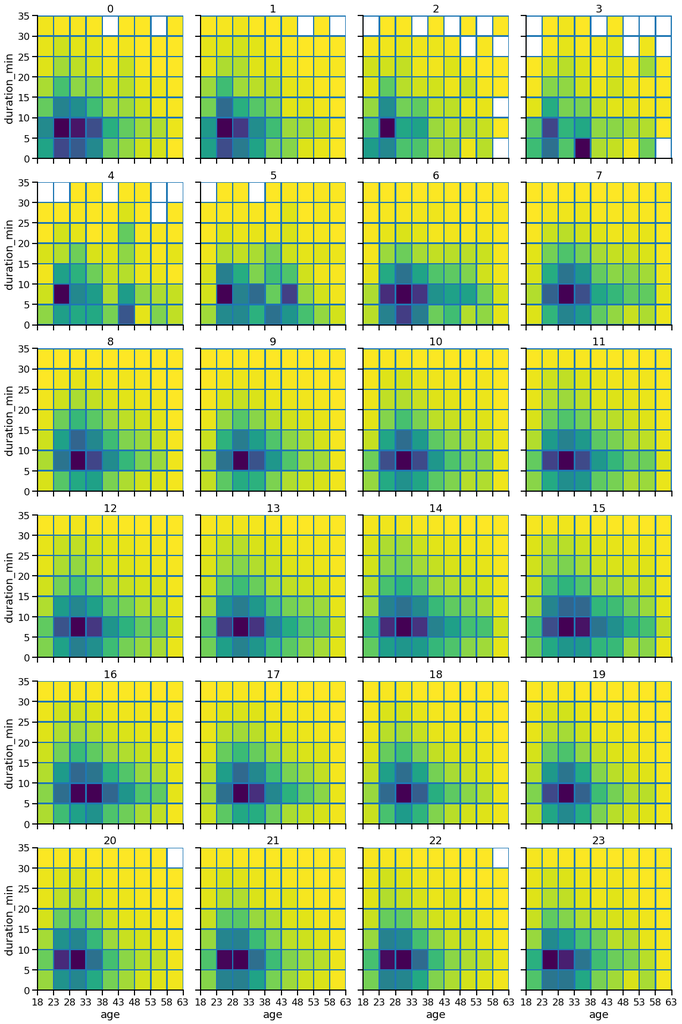

```python
bins_x = np.arange(18, df['age'].max()+5, 5)
bins_y = np.arange(0, df['duration_min'].max()+5, 5)
g = sb.FacetGrid(data=df, col='time_day', size=4, col_wrap=4)
g.map(plt.hist2d, 'age', 'duration_min', cmap='viridis_r', cmin=0.5, bins=[bins_x, bins_y]);
plt.xticks(np.arange(18, df['age'].max()+5, 5));
plt.yticks(np.arange(0, df['duration_min'].max()+5, 5));

g.set_titles('{col_name}');
```

From the faceting plots, we can see that during the day time, the trips clump up duration 5 – 10 minutes, and ages 23 – 38.  
However, during the midnight, the trips varies instead of clumping up in a specific range. Also during the midnight, there are less long duration trip and less trips from elder person.

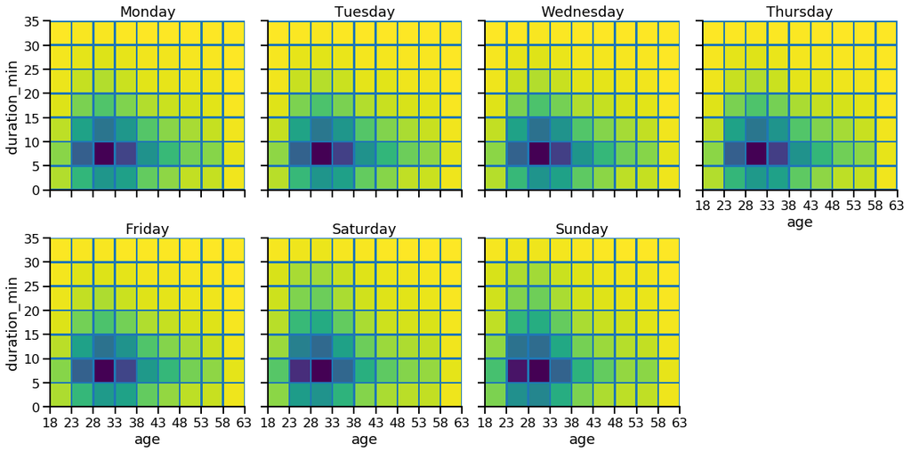

```python
bins_x = np.arange(18, df['age'].max()+5, 5)
bins_y = np.arange(0, df['duration_min'].max()+5, 5)
g = sb.FacetGrid(data=df, col='weekday', size=4, col_wrap=4)
g.map(plt.hist2d, 'age', 'duration_min', cmap='viridis_r', cmin=0.5, bins=[bins_x, bins_y]);
plt.xticks(np.arange(18, df['age'].max()+5, 5));
plt.yticks(np.arange(0, df['duration_min'].max()+5, 5));

g.set_titles('{col_name}');
```

Surprisingly, during the weekends, the trip duration and age distributions are not obviously different from days of week. The distributions cluster around duration 5 – 10 minutes, and ages 23 – 38.

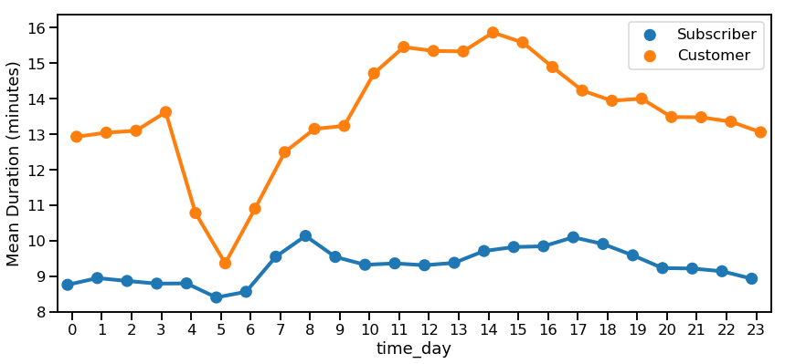

```python
plt.figure(figsize=(14,6))
sb.pointplot(data=df, x='time_day', y='duration_min', hue='user_type', dodge=0.3,ci=None)
plt.ylabel('Mean Duration (minutes)');
plt.legend(loc='best', bbox_to_anchor=(1, 1));
```

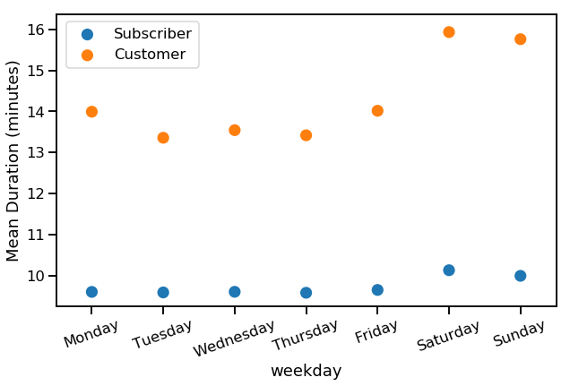

```python
plt.figure(figsize=(10,6))
sb.pointplot(data=df, x='weekday', y='duration_min', hue='user_type', dodge=False, linestyles='',ci=None)
plt.ylabel('Mean Duration (minutes)');
plt.legend(loc='best', bbox_to_anchor=(0.3, 1));
plt.xticks(rotation=20);
```

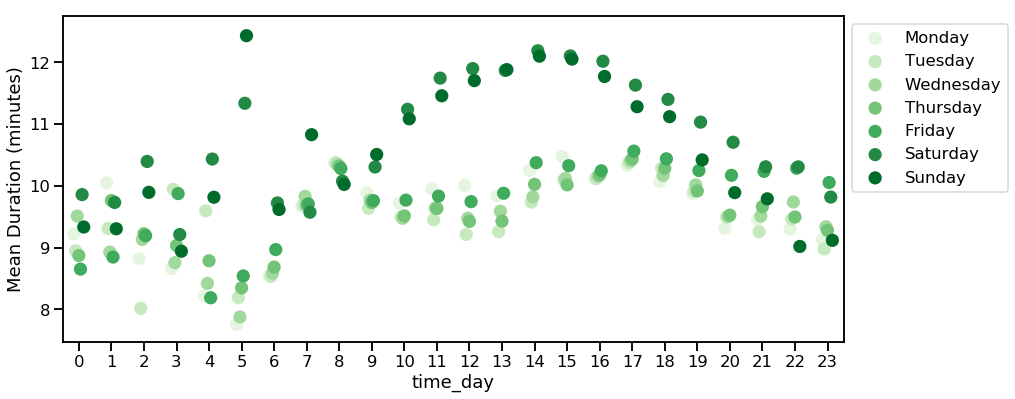

```python
plt.figure(figsize=(14,6))
sb.pointplot(data=df, x='time_day', y='duration_min', hue='weekday', dodge=0.3, linestyles='',ci=None, palette = 'Greens')
plt.ylabel('Mean Duration (minutes)');
plt.legend(loc='best', bbox_to_anchor=(1, 1));
```

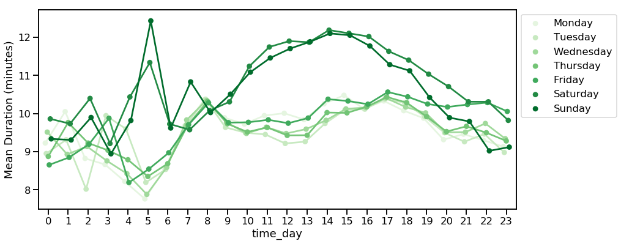

```python
plt.figure(figsize=(14,6))
sb.set_context(rc={"lines.linewidth": 1.5})
sb.pointplot(data=df, x='time_day', y='duration_min', hue='weekday', dodge=0.3,ci=None, palette = 'Greens')
plt.ylabel('Mean Duration (minutes)');
plt.legend(loc='best', bbox_to_anchor=(1, 1));
```

### Talk about some of the relationships you observed in this part of the investigation. Were there features that strengthened each other in terms of looking at your feature(s) of interest?

During the bivariate exploration, we didn’t see a big variation of trip duration mean at different time of the day. There doesn’t seem to be a strong correlation between time and trip duration mean. However, when we categorized by user type, we can see that trip duration mean varies in Customer group. There is an obvious increasing trend from 5am to 3pm, and decreasing trend from 4pm to 11pm.  
Also, the trip duration has a correlation with different time of the day especially during weekends.

### Were there any interesting or surprising interactions between features?

Looking back on faceting heatmap plots, there is no systematic interaction between time of day and age. But we can see that elder people are not likely to take a trip during early time of the day.  
From the line plot, there seems to be an interation between time of the day and days of week (workdays vs weekends).

```python
# save the cleaned data to csv
df.to_csv('fordgobike_clean.csv',index=False)
```